# Homework 7

### Due: Friday Dec 12 at 10pm

This assignment has a total of 27 pts possible. Your score out of 24 will noted and scaled to 5 points (maximum of 5).

### Question 1 – Conceptual (1 pt each)

**These are up to you to come up with good explanations for**

### Question 2 – Matching Correlations (2 pts)

IMS - Section 7.5, Question 7

1. r = -0.7 → (4). (b) r = 0.45 → (3). (c) r = 0.06 → (1). (d) r = 0.92 → (2).

### Question 3 – Cherry Trees (6 points)

The dataset below includes information on 31 black cherry trees felled in the Allegheny National Forest, Pennsylvania. For each tree, it includes three variables, one for each diameter (in), height (ft), and volume (cubic ft).

```r
## Cherry tree data
library(ggplot2)
library(dplyr)
cherry <- read.csv("https://collinn.github.io/data/cherry.csv")
```

**Part A:** Create two scatterplots of the data comparing diameter with volume and height with volume, in each case letting volume be the response variable. Based on these plots, which variable do you think would be a better predictor of volume?

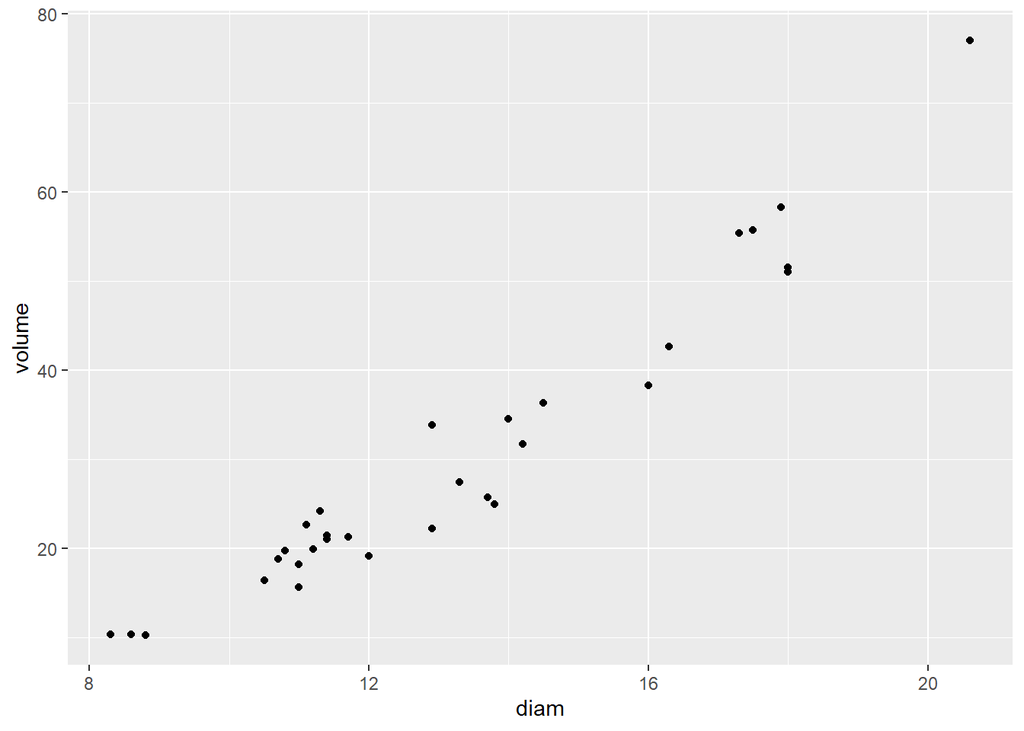

```r
ggplot(cherry, aes(x=diam, y=volume)) + geom_point()
```

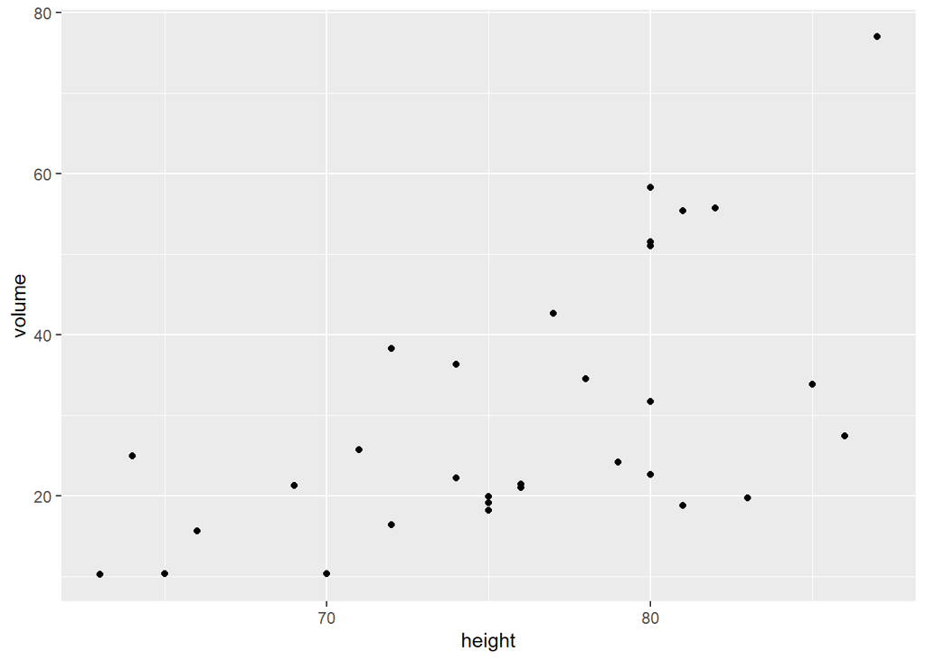

```r
ggplot(cherry, aes(x=height, y=volume)) + geom_point()
```

**Answer**: Probably diameter. The relationship looks strong and linear.

**Part B:** Create two linear models, ones for each of the plots created in Part A (that is, with volume as a response variable in both models). Based on the `summary()` output, which of these models has a higher $R^2$ value? Is this consistent with what you decided in Part A?

```r
fit1 = lm(data=cherry, volume~diam)
summary(fit1)
```

```
##
## Call:
## lm(formula = volume ~ diam, data = cherry)
##
## Residuals:
##    Min     1Q Median     3Q    Max
## -8.065 -3.107  0.152  3.495  9.587
##
## Coefficients:
##             Estimate Std. Error t value Pr(>|t|)
## (Intercept) -36.9435     3.3651  -10.98 7.62e-12 ***
## diam          5.0659     0.2474   20.48  < 2e-16 ***
## ---
## Signif. codes:  0 '***' 0.001 '**' 0.01 '*' 0.05 '.' 0.1 ' ' 1
##
## Residual standard error: 4.252 on 29 degrees of freedom
## Multiple R-squared:  0.9353, Adjusted R-squared:  0.9331
## F-statistic: 419.4 on 1 and 29 DF,  p-value: < 2.2e-16
```

```r
fit2 = lm(data=cherry, volume~height)
summary(fit2)
```

```
##
## Call:
## lm(formula = volume ~ height, data = cherry)
##
## Residuals:
##     Min      1Q  Median      3Q     Max
## -21.274  -9.894  -2.894  12.068  29.852
##
## Coefficients:
##             Estimate Std. Error t value Pr(>|t|)
## (Intercept) -87.1236    29.2731  -2.976 0.005835 **
## height        1.5433     0.3839   4.021 0.000378 ***
## ---
## Signif. codes:  0 '***' 0.001 '**' 0.01 '*' 0.05 '.' 0.1 ' ' 1
##
## Residual standard error: 13.4 on 29 degrees of freedom
## Multiple R-squared:  0.3579, Adjusted R-squared:  0.3358
## F-statistic: 16.16 on 1 and 29 DF,  p-value: 0.0003784
```

The linear model predicted volume with diameter gives us the larger $R^2$ value. This makes sense, as we can visually see the linear relationship in this scatterplot is stronger.

**Part C:** Using the model with the highest $R^2$ in Part B, write the linear equation for predicting a tree’s volume. Interpret both the slope and the intercept. Is the intercept meaningful in this case?

Using the first fit.

Predicted volume = -36.9435 + 5.0659 $\times$ diameter

Slope: For each 1-inch increase in tree diameter, we predict the volume to increase by 5.0659 cubic feet.

Intercept: For a tree with a diameter of 0 inches, we predict a volume of -36.94 cubic feet. This does not make sense. Diameter can’t be zero and volume can’t be negative.

**Part D:** In 1 or two sentences, generally describe what the model in part C is doing.

Predicting cherry tree volume using tree diameter. Generally, larger diameter = larger volume

**Part E:** Based on your $R^2$ value for model in Part C, do you think a model using both variables will perform much better than the regression model just using one predictor?

**Answer**: Probably not much. The $R^2$ is already very high, there isn’t much room for improvement.

**Part F:** Make a regression model using both predictors. Interpret the coefficients. Do you think the increase in $R^2$ warrants the increase in model complexity adding another variable?

```r
fit3 = lm(data=cherry, volume~height+diam)
summary(fit3)
```

```
##
## Call:
## lm(formula = volume ~ height + diam, data = cherry)
##
## Residuals:
##     Min      1Q  Median      3Q     Max
## -6.4065 -2.6493 -0.2876  2.2003  8.4847
##
## Coefficients:
##             Estimate Std. Error t value Pr(>|t|)
## (Intercept) -57.9877     8.6382  -6.713 2.75e-07 ***
## height        0.3393     0.1302   2.607   0.0145 *
## diam          4.7082     0.2643  17.816  < 2e-16 ***
## ---
## Signif. codes:  0 '***' 0.001 '**' 0.01 '*' 0.05 '.' 0.1 ' ' 1
##
## Residual standard error: 3.882 on 28 degrees of freedom
## Multiple R-squared:  0.948,  Adjusted R-squared:  0.9442
## F-statistic:   255 on 2 and 28 DF,  p-value: < 2.2e-16
```

Diameter Slope: For each 1-inch increase in tree diameter, we predict the volume to increase by 4.71 cubic feet, with height held constant.

Height Slope: For each 1ft increase in tree height, the predicted volume increases by 0.34 cubic feet, with diameter held constant.

Intercept: For a tree with a diameter of 0 inches and a height of 0 feet, we predict a volume of -58 cubic feet. This does not make sense. Diameter or height can’t be zero and volume can’t be negative.

### Question 4 – Cat Regression (12 points)

The problem includes a dataset with 144 cats, included with each observation is the sex of the cat, as well as body weight (kg) and heart weight (g).

```r
## Read in cat data
cats <- read.csv("https://collinn.github.io/data/cats.csv")
```

**Part A:** Use `lm()` to create a linear model in R predicting the weight of a cat’s heart using body weight as an explanatory variable. Write the formula for the regression line in context.

```r
lm(Hwt~Bwt, data=cats)
```

```
##
## Call:
## lm(formula = Hwt ~ Bwt, data = cats)
##
## Coefficients:
## (Intercept)          Bwt
##     -0.3567       4.0341
```

**Part B:** Interpret the slope in context.

Slope = 4.0341. For every increased kg of bodyweight, the prediction for heartweight goes up roughly 4.03g.

**Part C:** Interpret the intercept in context. Is the intercept meaningful?

For a 0kg bodyweight cat, the predicted heart weight is -.36g. No, this is not meaningful. Cats will not have a body weight of zero, heart weight can’t be negative.

**Part D:** What is the predicted heart weight of a cat that has a body weight of 3kg?

```r
-.3567 + 4.0341*3
```

```
## [1] 11.7456
```

**Part E:** What is the residual for a cat with a body weight of 3kg that actually has a heart weight of 12g. Is this an under- or over-prediction?

```r
12 - (-.3567 + 4.0341*3)
```

```
## [1] 0.2544
```

Positive residual = under prediction.

**Part F:** Create a linear model in R predicting the weight of a cat’s heart using the cat’s sex as an explanatory variable. Write the formula for the regression equation. Interpret the coefficients.

```r
lm(Hwt ~ Sex, data=cats)
```

```
##
## Call:
## lm(formula = Hwt ~ Sex, data = cats)
##
## Coefficients:
## (Intercept)         SexM
##       9.202        2.121
```

$\widehat{Hwt} = 9.202 + 2.121 \times$ **1**$_{Male}$

Intercept: We predict a heart weight of 9.202g for female cats.

Slope: Predicted heart weight for male cats is 2.121g more than female cats $\rightarrow$ 9.202+2.121 = 11.323g

**Part G:** Create a third linear model, this time including the cat’s sex in addition to body weight to predict heart weight. How do we interpret the intercept in this model?

```r
lm(Hwt ~ Bwt + Sex, data = cats)
```

```
##
## Call:
## lm(formula = Hwt ~ Bwt + Sex, data = cats)
##
## Coefficients:
## (Intercept)          Bwt         SexM
##     -0.4150       4.0758      -0.0821
```

For a female cat with a body weight of 0, we predict a heart weight of -.415g

**Part F:** Using the model from part C, what heart weight would you predict for:

- a male cat with a body weight of 3.2kg

```r
-.415 + 4.08*3.2 - .0821
```

```
## [1] 12.5589
```

- a female cat with a body weight of 2.4kg

```r
-.415 + 4.08*2.4
```

```
## [1] 9.377
```